# Discipline scientifiche

## Descrizione del dataset

Il dataset è composto dai seguenti elementi principali:

- **Discipline**: un insieme di settori scientifici appartenenti all’ingegneria, matematica, fisica, scienze naturali e scienze sociali.  
  Ogni disciplina è identificata da un nome univoco.
- **Size delle discipline**: a ciascuna disciplina è associato un valore numerico che rappresenta la sua “grandezza” nel dataset.  
  Questo valore non corrisponde necessariamente al numero esatto di articoli, ma è una misura aggregata/normalizzata della produttività scientifica della disciplina.
- **Matrice dei flussi** : una matrice quadrata in cui l’elemento $F_{ij}$ indica il flusso di citazioni **dalla disciplina $i$** verso **la disciplina $j$**.  
  In altre parole, $F_{ij}$ rappresenta quante volte gli articoli prodotti nella disciplina $i$ citano articoli appartenenti alla disciplina $j$.

```
## # A tibble: 8 × 3
##      id name                                   size
##   <int> <chr>                                 <dbl>
## 1     1 AGRICULTURE AND FOOD SCIENCE        875440.
## 2     2 ASTRONOMY AND ASTROPHYSICS          381255.
## 3     3 BASIC LIFE SCIENCES                2579591.
## 4     4 BASIC MEDICAL SCIENCES              268307.
## 5     5 BIOLOGICAL SCIENCES                1402123
## 6     6 BIOMEDICAL SCIENCES                2507916.
## 7     7 CHEMISTRY AND CHEMICAL ENGINEERING 3510294.
## 8     8 CIVIL ENGINEERING AND CONSTRUCTION  160903.
```

Visualizziamo un grafo totalmente connesso, DIRETTO  
(i pesi non sono simmetrici in entrambe le direzioni, nonostante esista sembre il grafo opposto)

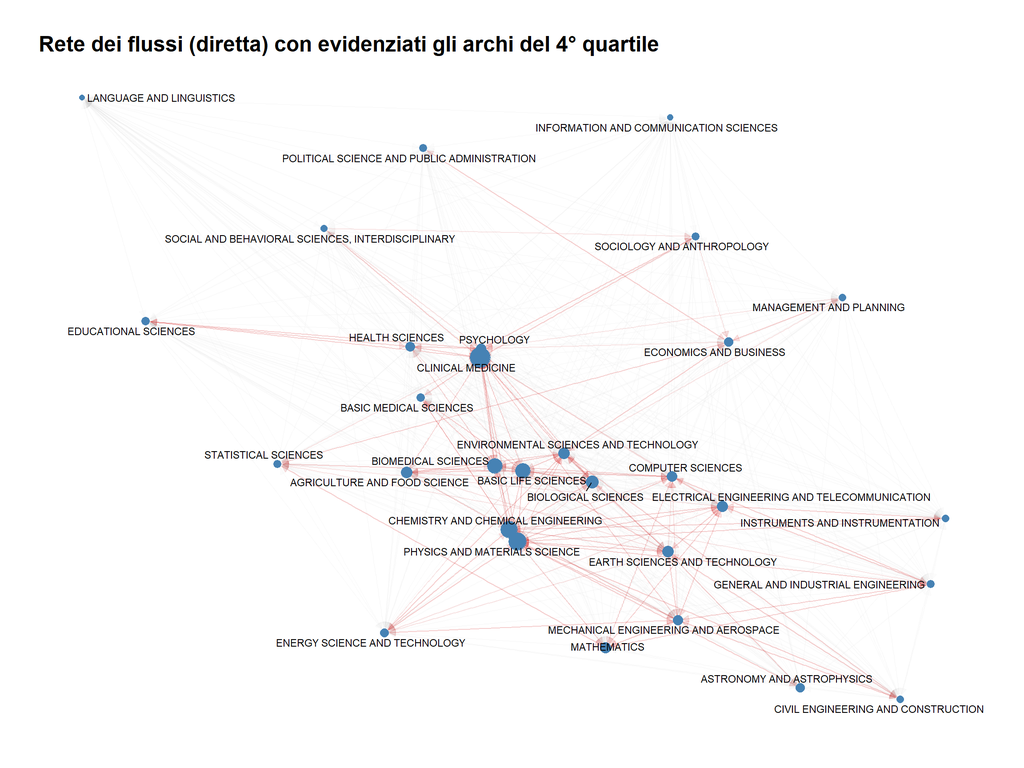

Ho fatto una visualizzazione esteticamente buona e abbastanza interpretabile, mettendo **rossi** solo gli archi con peso nel **4 quartile (Top 25%)**

# 1. Analisi delle citazioni

**Discipline con size maggiore :**  
Quindi con un maggior numero di articoli scientifici pubblicati

```
## # A tibble: 5 × 3
##      id name                                   size
##   <int> <chr>                                 <dbl>
## 1     9 CLINICAL MEDICINE                  6024742.
## 2    25 PHYSICS AND MATERIALS SCIENCE      4089318.
## 3     7 CHEMISTRY AND CHEMICAL ENGINEERING 3510294.
## 4     3 BASIC LIFE SCIENCES                2579591.
## 5     6 BIOMEDICAL SCIENCES                2507916.
```

**Flussi con peso citazione maggiore :**  
Qual’è la coppia di discipline, tale che ho il flusso maggiore di citazioni tra le 2 discipline (tolte autocitazione)

```
## # A tibble: 5 × 3
##     weight from_name                          to_name
##      <dbl> <chr>                              <chr>
## 1 1234379. BIOMEDICAL SCIENCES                CLINICAL MEDICINE
## 2 1107292. CLINICAL MEDICINE                  BIOMEDICAL SCIENCES
## 3 1086268. CLINICAL MEDICINE                  BASIC LIFE SCIENCES
## 4 1037640. CHEMISTRY AND CHEMICAL ENGINEERING PHYSICS AND MATERIALS SCIENCE
## 5 1011520. PHYSICS AND MATERIALS SCIENCE      CHEMISTRY AND CHEMICAL ENGINEERING
```

**Discipline che si autocitano maggiormente** Andiamo a guardare solo i self-loop, quindi osserviamo solo i flussi di citazione che vanno da una disciplina a se stessa

```
## # A tibble: 5 × 2
##   name                               self_citations
##   <chr>                                       <dbl>
## 1 CLINICAL MEDICINE                        8482322
## 2 PHYSICS AND MATERIALS SCIENCE            6163358.
## 3 CHEMISTRY AND CHEMICAL ENGINEERING       4352712.
## 4 BASIC LIFE SCIENCES                      3456087
## 5 BIOMEDICAL SCIENCES                      2356196
```

**Discipline che ricevono più citazioni** Sommiamo tutti i pesi citazione degli archi entranti per ogni disciplina, e facciamo la classifica delle discipline più citate da altre (tolte le autocitazioni)

```
## # A tibble: 30 × 2
##     rank name
##    <int> <chr>
##  1     1 BASIC LIFE SCIENCES
##  2     2 CLINICAL MEDICINE
##  3     3 BIOMEDICAL SCIENCES
##  4     4 PHYSICS AND MATERIALS SCIENCE
##  5     5 CHEMISTRY AND CHEMICAL ENGINEERING
##  6     6 BIOLOGICAL SCIENCES
##  7     7 ENVIRONMENTAL SCIENCES AND TECHNOLOGY
##  8     8 ELECTRICAL ENGINEERING AND TELECOMMUNICATION
##  9     9 EARTH SCIENCES AND TECHNOLOGY
## 10    10 AGRICULTURE AND FOOD SCIENCE
## # ℹ 20 more rows
```

**Discipline che tendono a citare altre discipline** Sommiamo tutti i pesi citazione degli archi uscenti per ogni disciplina, e facciamo la classifica delle discipline che più citano altre discipline (tolte le autocitazioni)

```
## # A tibble: 30 × 2
##     rank name
##    <int> <chr>
##  1     1 CLINICAL MEDICINE
##  2     2 BIOMEDICAL SCIENCES
##  3     3 CHEMISTRY AND CHEMICAL ENGINEERING
##  4     4 PHYSICS AND MATERIALS SCIENCE
##  5     5 BASIC LIFE SCIENCES
##  6     6 BIOLOGICAL SCIENCES
##  7     7 ENVIRONMENTAL SCIENCES AND TECHNOLOGY
##  8     8 AGRICULTURE AND FOOD SCIENCE
##  9     9 ELECTRICAL ENGINEERING AND TELECOMMUNICATION
## 10    10 HEALTH SCIENCES
## # ℹ 20 more rows
```

### Conlusioni analisi

In conclusione, le discipline dell’area biomedica e delle scienze fisiche emergono come i poli principali del sistema: non solo producono il maggior volume di pubblicazioni, ma risultano anche le più coinvolte negli scambi citazionali, sia come destinatarie che come sorgenti di citazioni. Questo conferma la loro centralità strutturale nella rete scientifica analizzata.

# 2/3. Normalizzazione dei pesi archi tramite il **Peso Atteso**

Il flusso atteso dal nodo $i$ al nodo $j$ è definito come:

$$E_{ij} = \frac{out_i \cdot in_j}{n}$$

dove:

- $out_i$ = outflow(somma pesi uscenti) della disciplina $i$, cioè il numero totale di citazioni emesse da $i$
- $in_j$ = inflow(somma pesi entranti) della disciplina $j$, cioè il numero totale di citazioni ricevute da $j$
- $n$ = flusso totale nella rete (somma di tutti i valori della matrice dei flussi)

Il termine $in_j / n$ rappresenta la probabilità che una citazione vada verso la disciplina $j$,  
mentre $out_i \cdot in_j / n$ è quindi il flusso “atteso” da $i$ verso $j$ in un modello puramente casuale basato sui volumi.

```
## # A tibble: 900 × 5
##   from_name                                  to_name weight expected weight_norm
##   <chr>                                      <chr>    <dbl>    <dbl>       <dbl>
## 1 LANGUAGE AND LINGUISTICS                   LANGUA… 8.07e4     223.       362.
## 2 INFORMATION AND COMMUNICATION SCIENCES     INFORM… 7.94e4     365.       217.
## 3 POLITICAL SCIENCE AND PUBLIC ADMINISTRATI… POLITI… 1.70e5    1081.       157.
## 4 SOCIAL AND BEHAVIORAL SCIENCES, INTERDISC… SOCIAL… 7.44e4     643.       116.
## 5 CIVIL ENGINEERING AND CONSTRUCTION         CIVIL … 1.28e5    1277.       100.
## 6 EDUCATIONAL SCIENCES                       EDUCAT… 2.13e5    2145.        99.2
## 7 MANAGEMENT AND PLANNING                    MANAGE… 1.15e5    1168.        98.8
## # ℹ 893 more rows
```

## Normalizzazione standard

$$\text{peso normalizzato} = \frac{\text{peso osservato}}{\text{peso
atteso}}$$

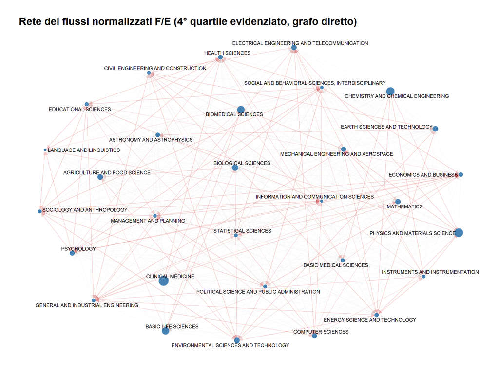

Anche qui ho messo in rosso solo i gli archi con weights nel 4 quadrante (top 25%),

Gli archi più pesanti **sembrano più equamente distribuiti sui vari nodi**,  
prima c’erano nodi con totale assenza di “archi pesanti”, adesso tutti i nodi li hanno.

## Normalizzazione con X-test

$$X_{ij} = \frac{F_{ij} - E_{ij}}{\sqrt{E_{ij}}}$$

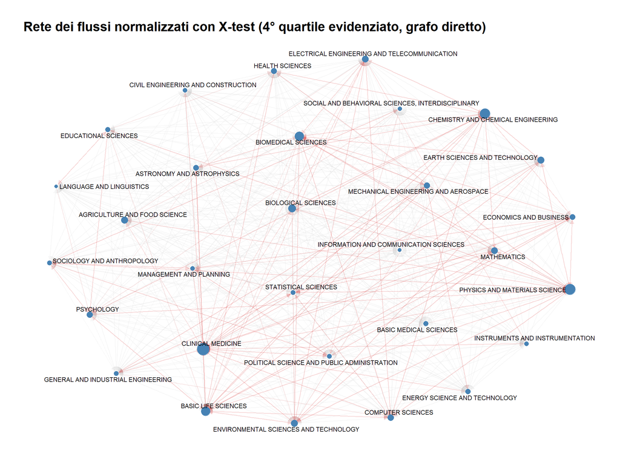

Molto simile alla normalizzazione precedente

# 4. Calcola l’entropia quadratica di Rao per ogni nodo

## Definizione di entropia quadratica di RAO

L’entropia quadratica di Rao è **una misura di eterogeneità del nodo**,

Più un nodo è **diverso** dai nodi del suo vicinato, **più è alta la sua eterogeneità**.

Se la relazione è una **relazione di approvazione**, come nel nostro caso :  
maggiore è il flusso di citazioni,**maggiore è l’approvazione di una disciplina verso un altra**,  
se una disciplina è approvata da discipline molto diverse tra loro, la disciplina ottiene maggiore **importanza trasversale**.

L’entropia quadratica di Rao è definita come:

$$R(p) = \sum_{i,j} p_i \, p_j \, d_{i,j}$$

dove:

- $p_i$ è la proporzione (probabilità) associata all’elemento $i$
- $d_{i,j}$ è la dissimilarità, = 1 se i!=j e = 0 se i == j, (cioè non sommiamo il prodotto delle probabilità se il vettore è lo stesso )

Per ogni nodo $i$, definiamo una distribuzione di probabilità sui suoi vicini:

$$p_{i,j} = \frac{a_{i,j}}{\sum_{k} a_{i,k}} = \frac{a_{i,j}}{d_i}$$

dove:

- $a_{i,j}$ è il peso dell’arco che va da $i$ a $j$
- $d_i = \sum_k a_{i,k}$ è il *grado pesato uscente* (out-strength) del nodo $i$

Da questa definizione segue che:

$$0 \le p_{i,j} \le 1
\qquad\text{e}\qquad
\sum_j p_{i,j} = 1$$

quindi

$$p_i = (p_{i,1}, p_{i,2}, \ldots, p_{i,n})$$

è una vera e propria distribuzione di probabilità di “outflow” associata al nodo $i$.  
**$p_{i}$ = Quanto è probabile che il nodo i citi un altro nodo j**

Nella formula di RAO:  
Stiamo quindi sommando tutte le **probabilità combinate** $p_{i,k} \, p_{j,k}$, **cioè la probabilità che i citi k e j citi k**  
=> Quindi che i e j citino lo stesso nodo k

Se chiamamiamo **distribuzione di probabilità combinata $p_{ij}(k)$ = quanto è probabile che i e j citino lo stesso nodo k**

$$p_{ij} = \left(
p_{i,1} \, p_{j,1},\;
p_{i,2} \, p_{j,2},\;
\ldots,\;
p_{i,n} \, p_{j,n}
\right)$$

Il prodotto $p_i \cdot p_j$ rappresenta la **somma dei valori della probabilità combinata** $p_{ij}$ .  
Più le due distribuzioni $p_i$ e $p_j$ assegnano probabilità **simili** agli stessi nodi $k$, più questa somma sarà **alta**;  
al contrario, probabilità molto **diverse** generano prodotti piccoli e la somma complessiva si **riduce**.

Quindi presi 2 nodi i e j, $p_i \cdot p_j$ è la somma dei valori della distribuzione combinata $p_{ij}$ :

- se la somma è **alta**, i due nodi hanno distribuzioni simili → citano gli altri nodi con probabilità simili → **nodi omogenei ( i e j simili )**;
- se la somma è **bassa**, le loro probabilità differiscono molto → citano nodi diversi → **nodi eterogenei ( i e j diversi )**.

**In conlusione**

I nodi con RAO minore sono **eterogenei/diversi** nella distribuzione delle citazioni verso altre discipline, rispetto agli altri

## Calcolo del RAO di ogni nodo

```r
library(tidygraph)
library(igraph)

#  estraggo la matrice di adiacenza
g_ig <- as.igraph(g)
A <- as.matrix(
  igraph::get.adjacency(g_ig, attr = "weight")
)
n <- nrow(A)


#  Distribuzioni p_i - divido per il totale della riga (ogni riga i è la distribuzione pi)
row_tot <- rowSums(A)
P <- A / row_tot

# similarità tra distribuzioni: p_i p_j = sum_k p_{i,k} p_{j,k}
S <- P %*% t(P)

#  Rao locale per ogni nodo i = sommo su tutti i j
rao_local <- rowSums(S)


# Visualizzo quelle più eterogenee

rao_tbl <- tibble(
  id   = 1:length(rao_local),
  name = nodes$name,
  rao  = rao_local
)


top10_interdisc <- rao_tbl %>%
  arrange(rao) %>%
  slice(1:10)

top10_interdisc
```

```
## # A tibble: 10 × 3
##       id name                                          rao
##    <int> <chr>                                       <dbl>
##  1    21 LANGUAGE AND LINGUISTICS                    0.876
##  2    19 INFORMATION AND COMMUNICATION SCIENCES      0.906
##  3    26 POLITICAL SCIENCE AND PUBLIC ADMINISTRATION 0.967
##  4     8 CIVIL ENGINEERING AND CONSTRUCTION          0.969
##  5    22 MANAGEMENT AND PLANNING                     0.971
##  6    13 EDUCATIONAL SCIENCES                        1.00
##  7    30 STATISTICAL SCIENCES                        1.01
##  8    17 GENERAL AND INDUSTRIAL ENGINEERING          1.03
##  9    29 SOCIOLOGY AND ANTHROPOLOGY                  1.04
## 10     2 ASTRONOMY AND ASTROPHYSICS                  1.08
```

Queste sono le **discipline più interdisciplinate**, quindi quelle con una distribuzione delle citazioni verso altri nodi più diversa rispetto al resto dei nodi.

Come visto in precedenza, la maggior parte dei nodi punta verso discipline medico-fisiche, mentre queste più umanistiche punteranno ad altre discipline umanistiche, **diversificandosi dal comportamento comune**